# Text Analysis

This note will examine

- Text Processing
- Text Representation Methods
- Visualization methods
- Text Characteristics

## Text Processing

Text processing is the first step for any natural language processing task. The aspects of text processing examined include:

- Text cleaning removes noise that can interfere with analysis
- Tokenization breaks text into meaningful units for processing
- Stop word removal reduces dimensionality while preserving meaning
- Stemming/lemmatization normalizes word forms for better analysis

```python
import pandas as pd
import numpy as np
import matplotlib.pyplot as plt
import seaborn as sns
from collections import Counter
import re
import string

# Import NLP libraries
import nltk
from nltk.tokenize import word_tokenize, sent_tokenize
from nltk.corpus import stopwords
from nltk.stem import PorterStemmer, WordNetLemmatizer
from nltk.util import ngrams

# Import spaCy for advanced NLP capabilities
# Setup Instructions:
# 1. Install spaCy: pip install spacy
# 2. Download English model: python -m spacy download en_core_web_sm
# 3. For better accuracy, download medium model: python -m spacy download en_core_web_md

import spacy
# Load English language model
nlp = spacy.load("en_core_web_sm")
# nlp = spacy.load("en_core_web_md")  # if using the medium mode.

from sklearn.feature_extraction.text import CountVectorizer, TfidfVectorizer
from sklearn.decomposition import LatentDirichletAllocation, NMF
from sklearn.manifold import TSNE
from sklearn.cluster import KMeans

from wordcloud import WordCloud
import plotly.express as px
import plotly.graph_objects as go


# Download required NLTK data (run once)
# nltk.download('punkt')
# nltk.download('punkt_tab')
# nltk.download('stopwords')
# nltk.download('wordnet')
# nltk.download('averaged_perceptron_tagger')
# nltk.download('vader_lexicon')
```

### Text cleaning

removes noise that can interfere with analysis

```python
# To illustrate text analysis methods, we will use the speech given by Geoffrey Hinton, Godfather of AI, at the awards ceremony of the 2024 Nobel Prize in Physics.
# https://www.nobelprize.org/prizes/physics/2024/hinton/speech/
speech = ['This year the Nobel committees in Physics and Chemistry have recognized the dramatic progress being made in a new form of Artificial Intelligence that uses artificial neural networks to learn how to solve difficult computational problems.',
 'This new form of AI excels at modeling human intuition rather than human reasoning and it will enable us to create highly intelligent and knowledgeable assistants who will increase productivity in almost all industries.',
 'If the benefits of the increased productivity can be shared equally it will be a wonderful advance for all humanity.',
 'Unfortunately, the rapid progress in AI comes with many short-term risks.',
 'It has already created divisive echo-chambers by offering people content that makes them indignant.',
 'It is already being used by authoritarian governments for massive surveillance and by cyber criminals for phishing attacks.',
 'In the near future AI may be used to create terrible new viruses and horrendous lethal weapons that decide by themselves who to kill or maim.',
 'All of these short-term risks require urgent and forceful attention from governments and international organizations.',
 'There is also a longer term existential threat that will arise when we create digital beings that are more intelligent than ourselves.',
 'We have no idea whether we can stay in control.',
 'But we now have evidence that if they are created by companies motivated by short-term profits, our safety will not be the top priority.',
 'We urgently need research on how to prevent these new beings from wanting to take control.',
 'They are no longer science fiction.']

cleaned_speech = []
for sentence in speech:
    sentence = re.sub(r'<[^>]+>', '', sentence)  # Remove HTML tags (if any)
    sentence = re.sub(r'http[s]?://(?:[a-zA-Z]|[0-9]|[$-_@.&+]|[!*\\(\\),]|(?:%[0-9a-fA-F][0-9a-fA-F]))+', '', sentence) # Remove URLs
    sentence = re.sub(r'\d+', '', sentence)  # Remove numbers (keeping text intact)
    sentence = re.sub(r'\s+', ' ', sentence).strip() # Remove extra whitespace
    sentence = sentence.lower()  # Convert to lowercase
    cleaned_speech.append(sentence)
cleaned_speech
```

```
['this year the nobel committees in physics and chemistry have recognized the dramatic progress being made in a new form of artificial intelligence that uses artificial neural networks to learn how to solve difficult computational problems.',
 'this new form of ai excels at modeling human intuition rather than human reasoning and it will enable us to create highly intelligent and knowledgeable assistants who will increase productivity in almost all industries.',
 'if the benefits of the increased productivity can be shared equally it will be a wonderful advance for all humanity.',
 'unfortunately, the rapid progress in ai comes with many short-term risks.',
 'it has already created divisive echo-chambers by offering people content that makes them indignant.',
 'it is already being used by authoritarian governments for massive surveillance and by cyber criminals for phishing attacks.',
 'in the near future ai may be used to create terrible new viruses and horrendous lethal weapons that decide by themselves who to kill or maim.',
 'all of these short-term risks require urgent and forceful attention from governments and international organizations.',
 'there is also a longer term existential threat that will arise when we create digital beings that are more intelligent than ourselves.',
 'we have no idea whether we can stay in control.',
 'but we now have evidence that if they are created by companies motivated by short-term profits, our safety will not be the top priority.',
 'we urgently need research on how to prevent these new beings from wanting to take control.',
 'they are no longer science fiction.']
```

### Tokenization

breaks text into meaningful units for processing

```python
word_tokens = [word_tokenize(sentence) for sentence in speech]   # word tokens
print(word_tokens[:1])

sentence_tokens = [sent_tokenize(sentence) for sentence in speech]   # sentence tokens
print(sentence_tokens[:2])  # same as original result, because text is already broken into sentences
```

```
[['This', 'year', 'the', 'Nobel', 'committees', 'in', 'Physics', 'and', 'Chemistry', 'have', 'recognized', 'the', 'dramatic', 'progress', 'being', 'made', 'in', 'a', 'new', 'form', 'of', 'Artificial', 'Intelligence', 'that', 'uses', 'artificial', 'neural', 'networks', 'to', 'learn', 'how', 'to', 'so…
[['This year the Nobel committees in Physics and Chemistry have recognized the dramatic progress being made in a new form of Artificial Intelligence that uses artificial neural networks to learn how to solve difficult computational problems.'], ['This new form of AI excels at modeling human intuitio…
```

### Remove Stop Words

- Stop words (the, is, at, which, on) are common but carry little meaning
- Removing them reduces feature space while preserving important content
- Improves model performance by focusing on content-bearing words
- Context-dependent: may not be appropriate for all tasks (e.g., language modeling)

```python
stopwords.words('english')[:10]    # stopwords in NLTK
```

```
['a', 'about', 'above', 'after', 'again', 'against', 'ain', 'all', 'am', 'an']
```

```python
filtered_tokens = []
for tokens in word_tokens:
    filtered = [word for word in tokens if word.lower() not in stopwords.words('english')]
    filtered_tokens.append(filtered)
print(word_tokens[0],
      '\n',
      '--------------------------------',
      '\n',
      filtered_tokens[0])
```

```
['This', 'year', 'the', 'Nobel', 'committees', 'in', 'Physics', 'and', 'Chemistry', 'have', 'recognized', 'the', 'dramatic', 'progress', 'being', 'made', 'in', 'a', 'new', 'form', 'of', 'Artificial', 'Intelligence', 'that', 'uses', 'artificial', 'neural', 'networks', 'to', 'learn', 'how', 'to', 'sol…
 --------------------------------
 ['year', 'Nobel', 'committees', 'Physics', 'Chemistry', 'recognized', 'dramatic', 'progress', 'made', 'new', 'form', 'Artificial', 'Intelligence', 'uses', 'artificial', 'neural', 'networks', 'learn', 'solve', 'difficult', 'computational', 'problems', '.']
```

### Stemming and Lemmatization

- Stemming: Reduces words to their root form (running -> run)
- Lemmatization: Reduces words to their dictionary form (better -> good)
- Both reduce vocabulary size and improve text similarity
- Lemmatization is more linguistically accurate but computationally expensive
- Choice depends on task requirements and computational constraints

```python
stemmer = PorterStemmer()
lemmatizer = WordNetLemmatizer()

example_words = ['running', 'better', 'studies', 'amazing', 'processing']
[(word, stemmer.stem(word),lemmatizer.lemmatize(word)) for word in example_words]
```

```
[('running', 'run', 'running'),
 ('better', 'better', 'better'),
 ('studies', 'studi', 'study'),
 ('amazing', 'amaz', 'amazing'),
 ('processing', 'process', 'processing')]
```

```python
stemmed_tokens = []
lemmatized_tokens = []
for tokens in filtered_tokens:
    stemmed = [stemmer.stem(word) for word in tokens]
    lemmatized = [lemmatizer.lemmatize(word) for word in tokens]
    stemmed_tokens.append(stemmed)
    lemmatized_tokens.append(lemmatized)

print(word_tokens[0],
      '\n',
      '--------------------------------',
      '\n',
      stemmed_tokens[0],
      '\n',
      '--------------------------------',
      '\n',
     lemmatized_tokens[0])
```

```
['This', 'year', 'the', 'Nobel', 'committees', 'in', 'Physics', 'and', 'Chemistry', 'have', 'recognized', 'the', 'dramatic', 'progress', 'being', 'made', 'in', 'a', 'new', 'form', 'of', 'Artificial', 'Intelligence', 'that', 'uses', 'artificial', 'neural', 'networks', 'to', 'learn', 'how', 'to', 'sol…
 --------------------------------
 ['year', 'nobel', 'committe', 'physic', 'chemistri', 'recogn', 'dramat', 'progress', 'made', 'new', 'form', 'artifici', 'intellig', 'use', 'artifici', 'neural', 'network', 'learn', 'solv', 'difficult', 'comput', 'problem', '.']
 --------------------------------
 ['year', 'Nobel', 'committee', 'Physics', 'Chemistry', 'recognized', 'dramatic', 'progress', 'made', 'new', 'form', 'Artificial', 'Intelligence', 'us', 'artificial', 'neural', 'network', 'learn', 'solve', 'difficult', 'computational', 'problem', '.']
```

## Text Representation Methods

Text must be converted to numbers to do machine learning. One approach involves

- BoW: Simple frequency-based representation, loses word order
- TF-IDF: Weights words by importance (frequency vs. rarity across documents)
- N-grams: Preserves some word order information

```python
vectorizer = CountVectorizer(
    lowercase=True,
    stop_words='english',
    max_features=50,  # Limit to top 50 features
    ngram_range=(1, 2))  # Include unigrams and bigrams
bow_matrix = vectorizer.fit_transform(cleaned_speech)

# Convert to dense array for easier viewing
bow_array = bow_matrix.toarray()

print("Bag of Words Matrix Shape:", bow_matrix.shape,'\n',
     "Feature names (vocabulary):",
      vectorizer.get_feature_names_out())

# Create a DataFrame for better visualization
bow_df = pd.DataFrame(bow_array,
                      columns=vectorizer.get_feature_names_out())
bow_df.iloc[:,:10]
```

```
Bag of Words Matrix Shape: (13, 50)
 Feature names (vocabulary): ['ai' 'artificial' 'beings' 'control' 'create' 'created' 'form'
 'governments' 'human' 'intelligent' 'longer' 'longer science'
 'longer term' 'maim' 'makes' 'makes indignant' 'massive'
 'massive surveillance' 'modeling' 'near' 'need' 'need research'
 'networks' 'networks learn' 'neural' 'neural networks' 'new' 'new beings'
 'new form' 'people' 'people content' 'phishing' 'phishing attacks'
 'physics' 'physics chemistry' 'prevent' 'prevent new' 'priority'
 'problems' 'productivity' 'productivity industries' 'productivity shared'
 'profits' 'progress' 'risks' 'short' 'short term' 'term' 'term risks'
 'used']
```

|  | ai | artificial | beings | control | create | created | form | governments | human | intelligent |
| --- | --- | --- | --- | --- | --- | --- | --- | --- | --- | --- |
| 0 | 0 | 2 | 0 | 0 | 0 | 0 | 1 | 0 | 0 | 0 |
| 1 | 1 | 0 | 0 | 0 | 1 | 0 | 1 | 0 | 2 | 1 |
| 2 | 0 | 0 | 0 | 0 | 0 | 0 | 0 | 0 | 0 | 0 |
| 3 | 1 | 0 | 0 | 0 | 0 | 0 | 0 | 0 | 0 | 0 |
| 4 | 0 | 0 | 0 | 0 | 0 | 1 | 0 | 0 | 0 | 0 |
| 5 | 0 | 0 | 0 | 0 | 0 | 0 | 0 | 1 | 0 | 0 |
| 6 | 1 | 0 | 0 | 0 | 1 | 0 | 0 | 0 | 0 | 0 |
| 7 | 0 | 0 | 0 | 0 | 0 | 0 | 0 | 1 | 0 | 0 |
| 8 | 0 | 0 | 1 | 0 | 1 | 0 | 0 | 0 | 0 | 1 |
| 9 | 0 | 0 | 0 | 1 | 0 | 0 | 0 | 0 | 0 | 0 |
| 10 | 0 | 0 | 0 | 0 | 0 | 1 | 0 | 0 | 0 | 0 |
| 11 | 0 | 0 | 1 | 1 | 0 | 0 | 0 | 0 | 0 | 0 |
| 12 | 0 | 0 | 0 | 0 | 0 | 0 | 0 | 0 | 0 | 0 |

### Term Frequency Inverse Document Frequency

Weights are the product of Term Frequency and Inverse Document Frequency

```python
tfidf_vectorizer = TfidfVectorizer(
    lowercase=True,
    stop_words='english',
    max_features=50,
    ngram_range=(1, 2))

# Fit and transform the cleaned texts
tfidf_matrix = tfidf_vectorizer.fit_transform(cleaned_speech)
tfidf_array = tfidf_matrix.toarray()

# Create a DataFrame for TF-IDF
tfidf_df = pd.DataFrame(
    tfidf_array,
    columns=tfidf_vectorizer.get_feature_names_out())
tfidf_df.iloc[:,:10]
```

|  | ai | artificial | beings | control | create | created | form | governments | human | intelligent |
| --- | --- | --- | --- | --- | --- | --- | --- | --- | --- | --- |
| 0 | 0.000000 | 0.540231 | 0.000000 | 0.000000 | 0.000000 | 0.000000 | 0.232938 | 0.000000 | 0.000000 | 0.000000 |
| 1 | 0.234669 | 0.000000 | 0.000000 | 0.000000 | 0.234669 | 0.000000 | 0.264637 | 0.000000 | 0.613748 | 0.264637 |
| 2 | 0.000000 | 0.000000 | 0.000000 | 0.000000 | 0.000000 | 0.000000 | 0.000000 | 0.000000 | 0.000000 | 0.000000 |
| 3 | 0.362099 | 0.000000 | 0.000000 | 0.000000 | 0.000000 | 0.000000 | 0.000000 | 0.000000 | 0.000000 | 0.000000 |
| 4 | 0.000000 | 0.000000 | 0.000000 | 0.000000 | 0.000000 | 0.395943 | 0.000000 | 0.000000 | 0.000000 | 0.000000 |
| 5 | 0.000000 | 0.000000 | 0.000000 | 0.000000 | 0.000000 | 0.000000 | 0.000000 | 0.368137 | 0.000000 | 0.000000 |
| 6 | 0.365063 | 0.000000 | 0.000000 | 0.000000 | 0.365063 | 0.000000 | 0.000000 | 0.000000 | 0.000000 | 0.000000 |
| 7 | 0.000000 | 0.000000 | 0.000000 | 0.000000 | 0.000000 | 0.000000 | 0.000000 | 0.438068 | 0.000000 | 0.000000 |
| 8 | 0.000000 | 0.000000 | 0.416331 | 0.000000 | 0.369185 | 0.000000 | 0.000000 | 0.000000 | 0.000000 | 0.416331 |
| 9 | 0.000000 | 0.000000 | 0.000000 | 1.000000 | 0.000000 | 0.000000 | 0.000000 | 0.000000 | 0.000000 | 0.000000 |
| 10 | 0.000000 | 0.000000 | 0.000000 | 0.000000 | 0.000000 | 0.411682 | 0.000000 | 0.000000 | 0.000000 | 0.000000 |
| 11 | 0.000000 | 0.000000 | 0.326831 | 0.326831 | 0.000000 | 0.000000 | 0.000000 | 0.000000 | 0.000000 | 0.000000 |
| 12 | 0.000000 | 0.000000 | 0.000000 | 0.000000 | 0.000000 | 0.000000 | 0.000000 | 0.000000 | 0.000000 | 0.000000 |

## Visualizations

### Word Frequency

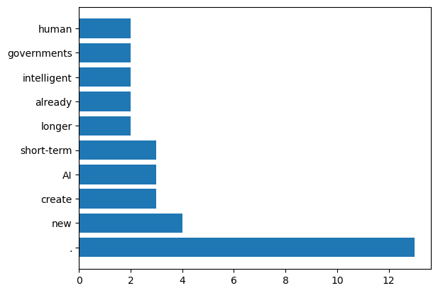

```python
all_words = []
for tokens in filtered_tokens:
    all_words.extend(tokens)
df = pd.DataFrame(Counter(all_words).items(), columns=['word','n'])
df_top_10 = df.sort_values('n', ascending=False).head(10)
plt.barh(df_top_10.word, df_top_10.n)
plt.show()
```

### Word Cloud

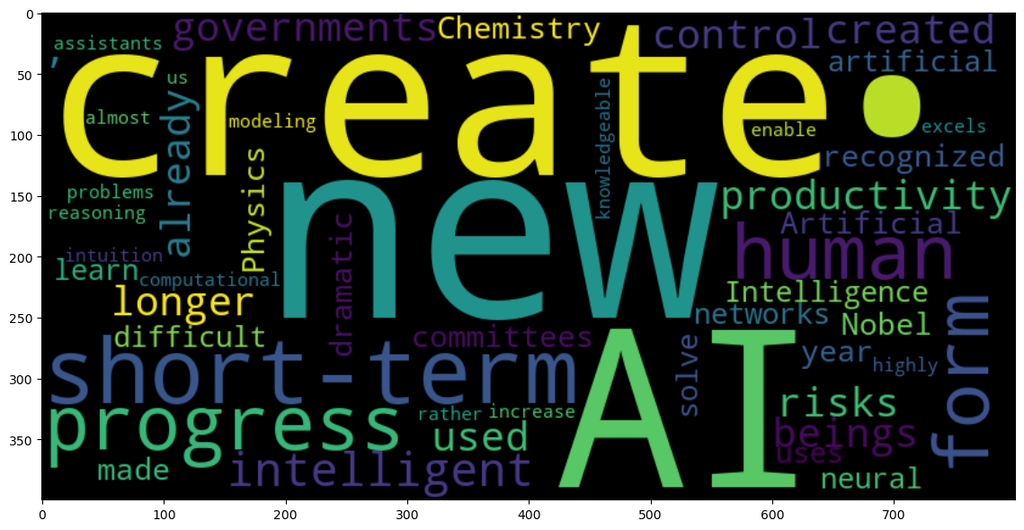

```python
wordcloud = WordCloud(
    width=800,
    height=400,
    background_color='black',
    max_words=50,
    colormap='viridis').generate_from_frequencies(Counter(all_words))
plt.figure(figsize=(12, 6))
plt.imshow(wordcloud, interpolation='bilinear')
plt.tight_layout()
plt.show()
```

### Document Similarity Analysis

```
      0     1     2     3     4     5     6     7     8     9     10    11  \
0   1.00  0.16  0.00  0.10  0.00  0.00  0.06  0.00  0.00  0.00  0.00  0.05
1   0.16  1.00  0.17  0.08  0.00  0.00  0.24  0.00  0.20  0.00  0.00  0.06
2   0.00  0.17  1.00  0.00  0.00  0.00  0.00  0.00  0.00  0.00  0.00  0.00
3   0.10  0.08  0.00  1.00  0.00  0.00  0.13  0.75  0.11  0.00  0.37  0.00
4   0.00  0.00  0.00  0.00  1.00  0.00  0.00  0.00  0.00  0.00  0.16  0.00
5   0.00  0.00  0.00  0.00  0.00  1.00  0.15  0.16  0.00  0.00  0.00  0.00
6   0.06  0.24  0.00  0.13  0.00  0.15  1.00  0.00  0.13  0.00  0.00  0.09
7   0.00  0.00  0.00  0.75  0.00  0.16  0.00  1.00  0.12  0.00  0.40  0.00
8   0.00  0.20  0.00  0.11  0.00  0.00  0.13  0.12  1.00  0.00  0.11  0.14
9   0.00  0.00  0.00  0.00  0.00  0.00  0.00  0.00  0.00  1.00  0.00  0.33
10  0.00  0.00  0.00  0.37  0.16  0.00  0.00  0.40  0.11  0.00  1.00  0.00
11  0.05  0.06  0.00  0.00  0.00  0.00  0.09  0.00  0.14  0.33  0.00  1.00
12  0.00  0.00  0.00  0.00  0.00  0.00  0.00  0.00  0.27  0.00  0.00  0.00

      12
0   0.00
1   0.00
2   0.00
3   0.00
4   0.00
5   0.00
6   0.00
7   0.00
8   0.27
9   0.00
10  0.00
11  0.00
12  1.00
```

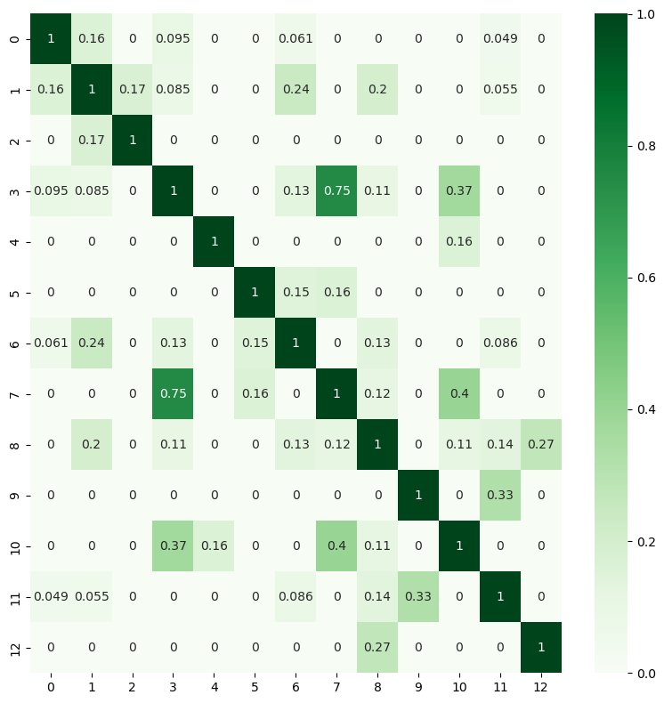

```python
# Calculate cosine similarity between documents using TF-IDF
from sklearn.metrics.pairwise import cosine_similarity
# Calculate similarity matrix
similarity_matrix = cosine_similarity(tfidf_matrix)
similarity_df = pd.DataFrame(similarity_matrix)
print(similarity_df.round(2))

# Visualize similarity matrix as heatmap
plt.figure(figsize=(8,8))
sns.heatmap(
    similarity_matrix,
    annot=True,
    cmap='Greens',)
plt.tight_layout()
plt.show()
```

### Topic Modeling with LDA

Uses Latent Dirichlet Allocation to identify underlying topics in the text

```
LDA Topics:
Topic 1: short term, short, term, ai, productivity, risks, term risks, governments, used, productivity shared
Topic 2: control, longer, longer science, beings, longer term, makes indignant, makes, people, people content, intelligent
LDA Topic Probabilities
              Topic 1   Topic 2
sentence 0   0.861486  0.138514
sentence 1   0.843895  0.156105
sentence 2   0.776522  0.223478
sentence 3   0.851489  0.148511
sentence 4   0.171872  0.828128
sentence 5   0.836155  0.163845
sentence 6   0.829564  0.170436
sentence 7   0.843138  0.156862
sentence 8   0.191716  0.808284
sentence 9   0.256323  0.743677
sentence 10  0.824474  0.175526
sentence 11  0.148244  0.851756
sentence 12  0.215476  0.784524
```

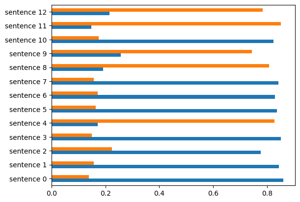

```python
lda_model = LatentDirichletAllocation(
    n_components=2,  # Number of topics
    random_state=617,
    max_iter=100)
lda_output = lda_model.fit_transform(tfidf_matrix)
feature_names = tfidf_vectorizer.get_feature_names_out()

print("LDA Topics:")
for topic_number, topic in enumerate(lda_model.components_):
    top_words_idx = topic.argsort()[-10:][::-1]  # Get top 10 words
    top_words = [feature_names[i] for i in top_words_idx]
    print(f"Topic {topic_number + 1}: {', '.join(top_words)}")

print("LDA Topic Probabilities")
topic_df = pd.DataFrame(lda_output, columns = ['Topic 1', 'Topic 2'])
topic_df.index = 'sentence ' + topic_df.index.astype(str)
print(topic_df)

topic_df.plot(kind = 'barh', legend = False)
plt.show()
```

### Cluster and Visualize in Two Dimensions

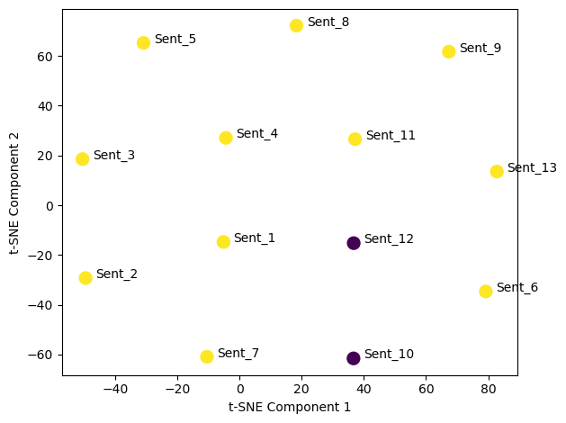

```python
# Use t-SNE to reduce tfidf matrix to two dimensions
tsne = TSNE(n_components=2, random_state=617, perplexity=min(30, len(cleaned_speech)-1))
tfidf_2d = tsne.fit_transform(tfidf_matrix.toarray())

# Cluster documents using K-means clustering
kmeans = KMeans(n_clusters=2, random_state=617)
clusters = kmeans.fit_predict(tfidf_matrix)

scatter = plt.scatter(tfidf_2d[:, 0], tfidf_2d[:, 1], c=clusters, cmap='viridis', s=100)
for i, (x, y) in enumerate(tfidf_2d):
    plt.annotate(f'Sent_{i+1}', (x, y), xytext=(8, 0), textcoords='offset points')
plt.xlabel('t-SNE Component 1')
plt.ylabel('t-SNE Component 2')
plt.tight_layout()
plt.show()
```

## Text Characteristics

### Basic Statistics

```python
characters = []
word = []
unique_words = []
average_word_length = []
lexical_diversity = []
for sentence in speech:
    words = sentence.split()
    char_count = len(sentence)
    word_count = len(words)
    unique_word_count = len(set(words))
    avg_word_length = sum([len(word) for word in words])/word_count
    lex_diversity = unique_word_count/word_count

    characters.append(char_count)
    word.append(word_count)
    unique_words.append(unique_word_count)
    average_word_length.append(avg_word_length)
    lexical_diversity.append(lex_diversity)
summary_df = pd.DataFrame({'Number of Characters':characters,
             'Number of Words': word,
            'Number of Unique Words':unique_words,
            'Average Word Length':average_word_length,
            'Lexical Diversity': lexical_diversity})
summary_df.index = 'Sentence ' + summary_df.index.astype(str)
summary_df
```

|  | Number of Characters | Number of Words | Number of Unique Words | Average Word Length | Lexical Diversity |
| --- | --- | --- | --- | --- | --- |
| Sentence 0 | 238 | 36 | 33 | 5.638889 | 0.916667 |
| Sentence 1 | 219 | 34 | 31 | 5.470588 | 0.911765 |
| Sentence 2 | 116 | 20 | 18 | 4.850000 | 0.900000 |
| Sentence 3 | 73 | 11 | 11 | 5.727273 | 1.000000 |
| Sentence 4 | 99 | 14 | 14 | 6.142857 | 1.000000 |
| Sentence 5 | 123 | 18 | 16 | 5.888889 | 0.888889 |
| Sentence 6 | 141 | 26 | 25 | 4.461538 | 0.961538 |
| Sentence 7 | 117 | 15 | 14 | 6.866667 | 0.933333 |
| Sentence 8 | 134 | 22 | 21 | 5.136364 | 0.954545 |
| Sentence 9 | 47 | 10 | 10 | 3.800000 | 1.000000 |
| Sentence 10 | 136 | 24 | 23 | 4.708333 | 0.958333 |
| Sentence 11 | 90 | 16 | 15 | 4.687500 | 0.937500 |
| Sentence 12 | 35 | 6 | 6 | 5.000000 | 1.000000 |

### Readability

Assesses the difficulty of text based on length of words, length of sentences, and word complexity.

```python
from readability.readability import Readability
rd = Readability(''.join(speech).replace('.','. '))  # combine all sentences from speech into a single paragraph and add space after period
print('Flesch',rd.flesch().score,'\n'
      'Flesch-Kincaid',rd.flesch_kincaid().score,'\n'
      'Gunning Fog Index',rd.gunning_fog().score,'\n'
      #'SMOG Index',rd.smog().score,'\n'  # needs 30 sentences
      'Coleman-Liau', rd.coleman_liau().score,'\n'
      'Dale Chall', rd.dale_chall().score)
```

```
Flesch 41.79532967032969
Flesch-Kincaid 12.051550671550672
Gunning Fog Index 15.055433455433457
Coleman-Liau 13.33301587301587
Dale Chall 10.111945177045175
```

### Parts of Speech

- Parts of Speech (POS) tagging is the intricate process of assigning grammatical categories, such as nouns, verbs, adjectives, and adverbs, to each word in a sentence.
- This process is not just a simple labeling task; it involves sophisticated algorithms and linguistic rules to accurately identify the role of each word within its specific context.

```python
from nltk.tokenize import word_tokenize
from nltk.tag import pos_tag
pos_tags = pos_tag(word_tokenize(speech[0]))
pd.DataFrame(pos_tags,columns=['Word','POS']).head(10)
```

|  | Word | POS |
| --- | --- | --- |
| 0 | This | DT |
| 1 | year | NN |
| 2 | the | DT |
| 3 | Nobel | NNP |
| 4 | committees | NNS |
| 5 | in | IN |
| 6 | Physics | NNP |
| 7 | and | CC |
| 8 | Chemistry | NNP |
| 9 | have | VBP |

```python
doc = nlp(speech[0])
[(token.text, token.pos_, token.lemma_, token.dep_) for token in doc][:10]
```

```
[('This', 'DET', 'this', 'det'),
 ('year', 'NOUN', 'year', 'npadvmod'),
 ('the', 'DET', 'the', 'det'),
 ('Nobel', 'PROPN', 'Nobel', 'compound'),
 ('committees', 'NOUN', 'committee', 'nsubj'),
 ('in', 'ADP', 'in', 'prep'),
 ('Physics', 'PROPN', 'Physics', 'pobj'),
 ('and', 'CCONJ', 'and', 'cc'),
 ('Chemistry', 'PROPN', 'Chemistry', 'conj'),
 ('have', 'AUX', 'have', 'aux')]
```

### Named Entity Recognition

- Aims to identify and classify named entities mentioned within unstructured text
- These entities are categorized into predefined groups such as the names of persons, organizations, locations, expressions of times, quantities, monetary values, percentages, and more

```python
doc = nlp(speech[0])
[(ent.text, ent.label_, spacy.explain(ent.label_)) for ent in doc.ents]
```

```
[('This year', 'DATE', 'Absolute or relative dates or periods'),
 ('Nobel', 'WORK_OF_ART', 'Titles of books, songs, etc.'),
 ('Physics', 'ORG', 'Companies, agencies, institutions, etc.'),
 ('Chemistry', 'ORG', 'Companies, agencies, institutions, etc.'),
 ('Artificial Intelligence', 'ORG', 'Companies, agencies, institutions, etc.')]
```

## Summary

This note examined

- Text Processing
- Text Representation Methods
- Visualization methods
- Text Characteristics

This file was generated using Python 3.11.13 on Windows 10 with the following libraries: matplotlib 3.10.0, nltk 3.9.1, numpy 1.26.4, pandas 2.3.1, plotly 6.0.1, readability 0.3.2, scikit-learn 1.7.1, seaborn 0.13.2, spacy 3.7.2, wordcloud 1.9.4